# Mini Project 4-Exploration of Identifying Biopsy Scans and Possibly Expanding Healthcare Access

Madeleine Guettler

5/1/2022

```r
library(tidyverse)
library(tidymodels)
```

```r
library(rpart.plot)
library(ggridges)
library(vip)
library(mdsr)
library(mosaic)
library(readr)
library(dplyr)
library(baguette)
library(parsnip)
library(xgboost)
library(tune)
```

# Introduction

The following data set is a data set that focuses on tumor biopsy images. The data set contains the diagnosis of each image collected and also a series of measurements of the tumor scanned in the biopsy scan done. It’s important for us to study the characteristics of a tumor, because it can help us hopefully identify if there’s certain characteristics that make it more likely for a tumor to be malignant or benign. And hopefully through first looking at some of our variables through visualization to take a guess on some potentially clear determinants of benign vs. malignant and then through machine learning concepts create a model that through certain collection of measurements is able to pretty accurately identify a tumor as malignant or benign. This study is important because if we can create a model that identifies tumors with high accuracy, it not only would allow us to identify a greater amount of tumors, but also we could possibly expand healthcare access to lower income individuals as if a machine identifies the tumors, we could possibly lower the cost in the service meaning more people could afford it.

So what does this data set include? This data set focuses on collecting measurements of: 1. `radius` 2. `texture` 3. `perimeter` 4. `area` 5. `smoothness` 6.`concavity` 7. `compactness` 8. `concave points` 9. `symmetry` 10. `fractal dimension` And from these measurements variables containing the mean, standard error, and worst is calculated/found

So to get started we are going to download and assign our dataset to the variable `cancer`

```r
cancer <- read_csv("cancer.csv") # Here we are reading our downloaded dataset and assigning it to the variable cancer
```

**Note**: [This dataset was gotten from,](https://colab.research.google.com/drive/1SMFleT-baqWdCuR19IkDeyvRSeXFxwf9?usp=sharing#scrollTo=0-SoD9EQw5Ie)

```r
head(cancer) # Using head() to open a snapshot of what our dataset looks like.
```

```
## # A tibble: 6 × 33
##         id diagnosis radius_mean texture_mean perimeter_mean area_mean
##      <dbl> <chr>           <dbl>        <dbl>          <dbl>     <dbl>
## 1   842302 M                18.0         10.4          123.      1001
## 2   842517 M                20.6         17.8          133.      1326
## 3 84300903 M                19.7         21.2          130       1203
## 4 84348301 M                11.4         20.4           77.6      386.
## 5 84358402 M                20.3         14.3          135.      1297
## 6   843786 M                12.4         15.7           82.6      477.
## # … with 27 more variables: smoothness_mean <dbl>, compactness_mean <dbl>,
## #   concavity_mean <dbl>, concave points_mean <dbl>, symmetry_mean <dbl>,
## #   fractal_dimension_mean <dbl>, radius_se <dbl>, texture_se <dbl>,
## #   perimeter_se <dbl>, area_se <dbl>, smoothness_se <dbl>,
## #   compactness_se <dbl>, concavity_se <dbl>, concave points_se <dbl>,
## #   symmetry_se <dbl>, fractal_dimension_se <dbl>, radius_worst <dbl>,
## #   texture_worst <dbl>, perimeter_worst <dbl>, area_worst <dbl>, …
```

So in looking at a perlimary view of the dataset, there are a lot of variables and also currently diagnosis is using M for malignant or B for benign. However, let’s mutate this so that the classification is either 1 for positive for a cancerous tumor or malignant or 0 for negative for a cancerous tumor or benign. Additionally, as there are 33 variables let’s just look at the variables that focus specifically on averages of the different categories available. So this would be the variables: 1. `diagnosis`: Whether the tumor was diagnosed as malignant (1) or benign (0) 2. `perimeter_mean`: The average perimeter of cells in that particular biopsy 3. `radius_mean`: The average radius of cells in that particular biopsy 4. `texture_mean`: The average texture of cells in that particular biopsy 5. `area_mean`: The average area of cells in that particular biopsy 6. `smoothness_mean`: The average smoothness of cells in that particular biopsy 7. `concavity_mean`: The average concavity of cells in that particular biopsy 8. `symmetry_mean`: The average symmetry of cells in that particular biopsy

We are not going to include the variable `id` because we in this case do not really need it as we are simply trying to explore which features are singificant in determining if malignant or benign.

So let’s put this into practice.

**Note**: I am choosing in this case to overwrite original dataset because we are not going to go back in this exploration to the other variables. However, normally this would be something that is not advised to do.

```r
cancer = cancer %>%
  select(diagnosis, perimeter_mean, radius_mean,texture_mean, area_mean, smoothness_mean, concavity_mean, symmetry_mean) %>% # Here I am selecting only the variables I want
  mutate(diagnosis = ifelse(diagnosis == "M", 1, 0)) # Here I am using mutate() and ifelse() functions to change the values in diagnosis to be either 1 or 0 if malignant or benign

cancer
```

```
## # A tibble: 569 × 8
##    diagnosis perimeter_mean radius_mean texture_mean area_mean smoothness_mean
##        <dbl>          <dbl>       <dbl>        <dbl>     <dbl>           <dbl>
##  1         1          123.         18.0         10.4     1001           0.118
##  2         1          133.         20.6         17.8     1326           0.0847
##  3         1          130          19.7         21.2     1203           0.110
##  4         1           77.6        11.4         20.4      386.          0.142
##  5         1          135.         20.3         14.3     1297           0.100
##  6         1           82.6        12.4         15.7      477.          0.128
##  7         1          120.         18.2         20.0     1040           0.0946
##  8         1           90.2        13.7         20.8      578.          0.119
##  9         1           87.5        13           21.8      520.          0.127
## 10         1           84.0        12.5         24.0      476.          0.119
## # … with 559 more rows, and 2 more variables: concavity_mean <dbl>,
## #   symmetry_mean <dbl>
```

So although, I have added some comments in my code, I want to go over in greater detail what I have just done. So first of all I have assigned my new dataset to the variable cancer. Secondly let’s go over what I actually did to the original dataset. Instead of first mutating my variables I wanted to first select all of the variables I wanted. I especially chose this first because in order to mutate the diagnosis values I would have needed to select diagnosis and if I only chose to select this variable and not the rest I would have not been able to select the rest of the variables after the mutation due to the other columns no longer being there as select will only take the columns you want and not include the rest. Next I mutate my diagnosis variable. The way I do this is with the function `mutate()`. I then use the handy function `ifelse()` where I am telling it if the value is equal to M assign the value 1, and everything else assign the value 0 to.

So now that we’ve gotten the dataset we would like to work with let’s explore some data to see what features seem potentially significant for diagnosising cancerous tumors.

When thinking about malignant tumors, I would think that size has some influence to the tumor being benign or malignant. So let’s start with looking at the relationship between `radius mean` and `diagnosis`.

So let’s create a density plot to view the relationship between radius and diagnosis. I am choosing a density plot because it will give us a clear sense of how many times a tumor with a certain radius was categorized as benign or malignant and hopefully we will see a clear pattern.

The way we are going to do this is by assigning `radius mean` to the x variable in our `ggplot`. Then when we call our `geom_density()` function we want to be able to distinguish between malignant and benign so we will use our `fill` aesthetic to make the density graphs filled with two different colors for benign and malignant.

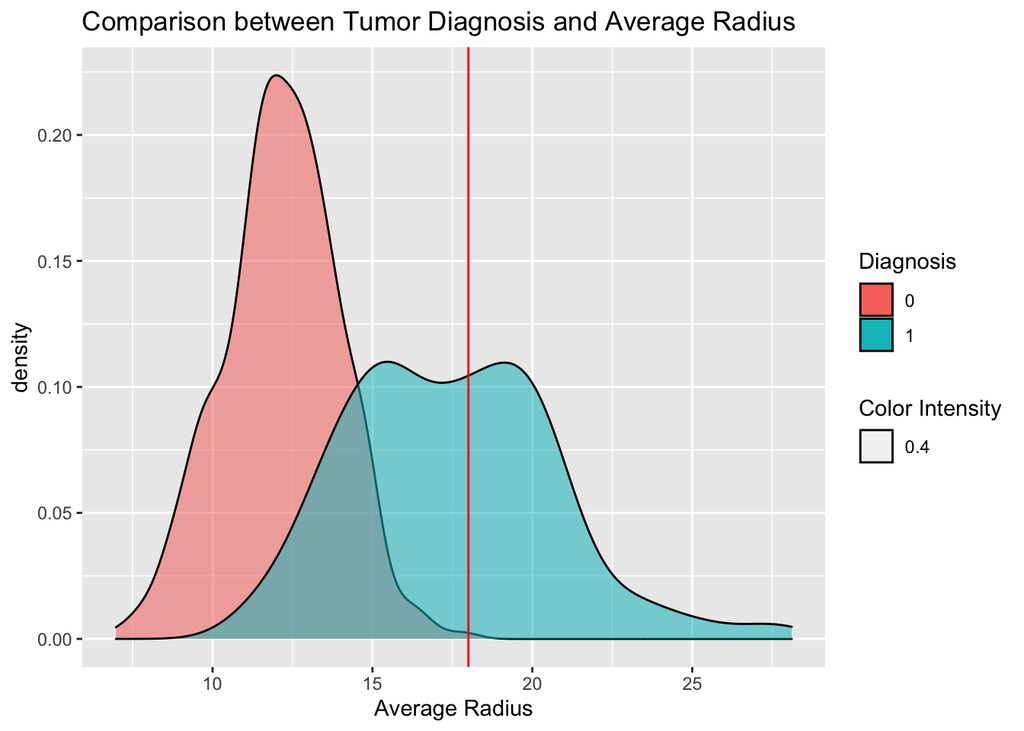

```r
cancer %>%
  ggplot(aes(x = radius_mean)) + # assigning radius_mean to x variable
  geom_density(aes(fill = factor(diagnosis), alpha = 0.4)) + # adding in fill aesthetic to color code our two graphs
  geom_vline(xintercept = 18, color = "red") + # Adding this line in because I want to distinguish where the diagnoses seem to start changing to malignant
  labs(title = "Comparison between Tumor Diagnosis and Average Radius",
       x = "Average Radius",
       fill = "Diagnosis",
       alpha = "Color Intensity") # simply adding some labels
```

So there seems to be some of a positive correlation between average radius and diagnosis status where it seems that as the average radius increases, it’s more likely to be malignant. Where we can even just see with the vertical line I put in at about 18 radius, it becomes exclusively manignant.

So now, let’s look at another possible variable that could be correlated. Let’s look at `texture_mean` next. We are going to use a density plot again.

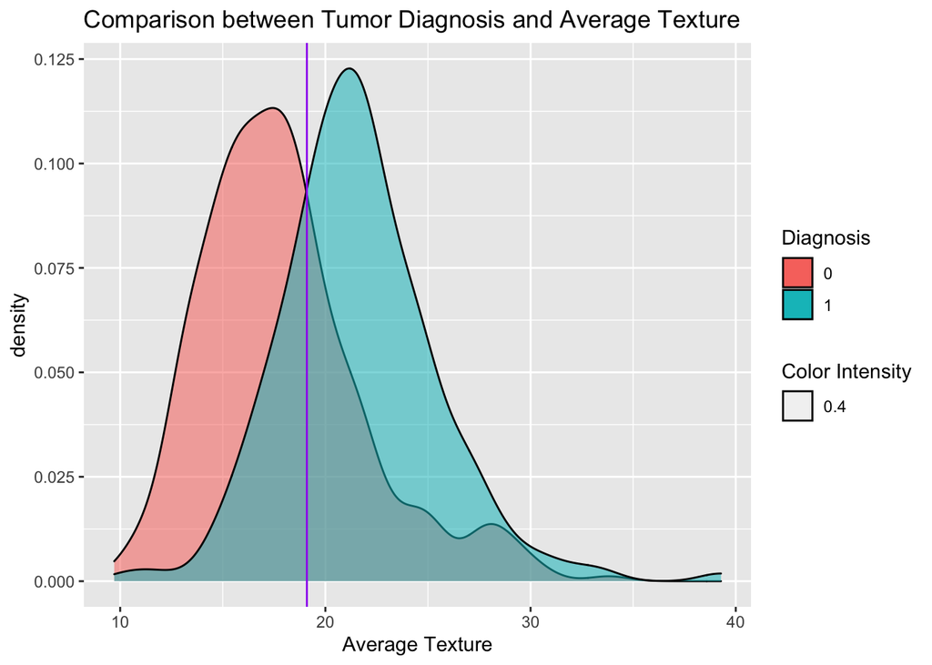

```r
cancer %>%
  ggplot(aes(x = texture_mean)) + # Assigning texture_mean to x variable
  geom_density(aes(fill = factor(diagnosis), alpha = 0.4)) + # adding in fill aesthetic to color code our two graphs
  geom_vline(xintercept = 19.1, color = "purple") + # adding in verticle line to give an estimate of where it seems to start changing in diagnoses
  labs(title = "Comparison between Tumor Diagnosis and Average Texture",
       x = "Average Texture",
       fill = "Diagnosis",
       alpha = "Color Intensity") # adding labels.
```

So in this case when looking at this density graph it seems that when we get past an average texture of ~ 19.1 it becomes more likely that the tumor is malignant. So somewhat significant in predicting diagnosis.

Let’s look at the `symmetry_mean` variable next.

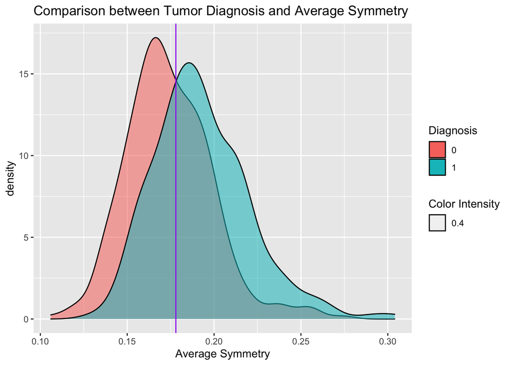

```r
cancer %>%
  ggplot(aes(x = symmetry_mean)) + # assigning symmetry_mean to x variable
  geom_density(aes(fill = factor(diagnosis), alpha = 0.4)) + # adding in fill aesthetic to color code our two graphs
  geom_vline(xintercept = 0.178, color = "purple") + # Estimating a vertical line to give a guess of where diagnoses seems to change
  labs(title = "Comparison between Tumor Diagnosis and Average Symmetry",
       x = "Average Symmetry",
       fill = "Diagnosis",
       alpha = "Color Intensity") # adding labels
```

While this density plot doesn’t have as high of steep drop as average texture and radius do, it seems that after an average symmetry score of ~ 0.178 it becomes more likely that the tumor is malignant.

Let’s look at one more variable before building some models. For this visual let’s look at `concavity_mean`.

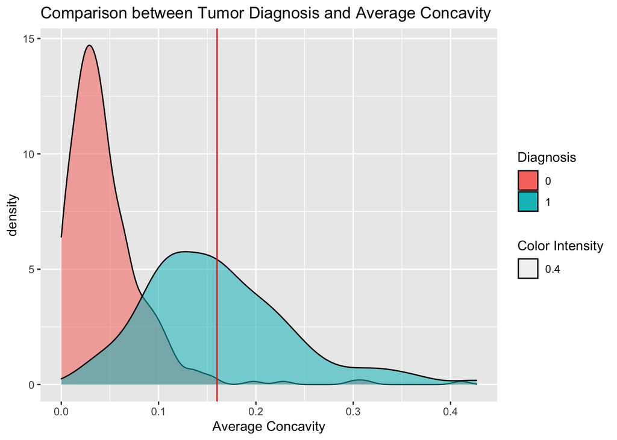

```r
cancer %>%
  ggplot(aes(x = concavity_mean)) + # assigning concavity mean to x variable
  geom_density(aes(fill = factor(diagnosis), alpha = 0.4)) + # adding in fill aesthetic to color code our two graphs
  geom_vline(xintercept = 0.16, color = "red") + # Estimating where it seems to start changing in diagnoses
  labs(title = "Comparison between Tumor Diagnosis and Average Concavity",
       x = "Average Concavity",
       fill = "Diagnosis",
       alpha = "Color Intensity") # adding labels
```

So with this variable there seems to be a bit more of a distinction between malignant and benign. There are clearly some outliers past our vertical line placed at 0.16 but for the most part benign tumors seem to group between a mean value of 0.0 and 0.16. My guess with the outlier values in the benign category there are other factors that are categorizing it as benign such as maybe average radius.

So now that we’ve explored our variables a bit let’s start creating some models. First though to recap from this exploration of data we can conclude that some features that seem to have some significance in diagnosis categorization are average radius, average symmetry, and average concavity.

Let’s start with a very simple model. So because diagnosis is categorical it wouldn’t actually make sense for us to explore a linear regression model as this is meant more for numerical values. Instead we are going to start with a decision tree as we can set the mode to “classification” instead of “regression”

To start with we need to split our data. We are also going to add a `set.seed(9)` so that we can replicate the data.

```r
set.seed(9)
# 1 Splitting Data
cancer_split = initial_split(cancer, prop = 0.7) #Splitting data so that training dataset is 70% of our original dataset and testing dataset is 30% of our original dataset

cancer_train = training(cancer_split) # assigning training dataset to variable cancer_train
cancer_test = testing(cancer_split) # assigning testing dataset to variable cancer_test
```

```r
# Fitting the model
cancer_tree = decision_tree() %>% # Choosing to keep all the defaults in our decision tree function
  set_mode(mode = "classification") %>% # Need to set our mode manually to classification because our diagnosis variable is categorical
  fit(factor(diagnosis) ~ radius_mean, data = cancer_train) # We are using our training data NOT our testing data. We need our testing dataset for assessing how accurate our model is in predicting diagnoses.
```

**Note**: We have to add the `factor()` function to the variable `diagnosis` because when we use a decision tree and set the mode to `classification` we made to make sure that the variable is classified as categorical.

Now that we’ve fitting our model let’s create a prediction using our testing dataset

```r
# Generate Predictions
diagnosis_pred = cancer_tree %>%
  predict(new_data = cancer_test)

diagnosis_pred
```

```
## # A tibble: 171 × 1
##    .pred_class
##    <fct>
##  1 0
##  2 1
##  3 0
##  4 1
##  5 1
##  6 0
##  7 0
##  8 1
##  9 1
## 10 0
## # … with 161 more rows
```

Let’s see now how our model did. So when we add in our prediction category in our dataset, when calling the model, we need to call `.pred_class`. We are first going to add in our new prediction column. And let’s also select the columns we used to predict and see how it compares visually.

```r
cancer_test %>%
  mutate(diagnosis_pred = diagnosis_pred$.pred_class) %>% # We are adding our generated predictions to a new column `cancer_pred`
  select(diagnosis, diagnosis_pred, radius_mean) # Selecting the relevant columns
```

```
## # A tibble: 171 × 3
##    diagnosis diagnosis_pred radius_mean
##        <dbl> <fct>                <dbl>
##  1         1 0                     11.4
##  2         1 1                     20.3
##  3         1 0                     12.4
##  4         1 1                     16.0
##  5         1 1                     19.2
##  6         1 0                     14.5
##  7         1 0                     14.7
##  8         1 1                     15.3
##  9         1 1                     18.6
## 10         0 0                     13.0
## # … with 161 more rows
```

So just, looking at the data frame it looks like our predictions are varying in accuracy. It looks like in general our model is predicting a benign value when the radius is mean is under 15 and when over it’s predicting it as malignant. It looks like though the predicition accuracy is going down in some cases because there are certain times when the radius mean is under 15 and the tumor is actually malignant.

Let’s take a look though of how accurate it actually was.

```r
cancer_test %>%
  mutate(diagnosis_pred = diagnosis_pred$.pred_class) %>% # We are adding our generated predictions to a new column `cancer_pred`
  accuracy(estimate = diagnosis_pred, truth = factor(diagnosis)) # Creating an accuracy score using `diagnosis_pred` and `diagnosis`. We once again have to make sure that our diagnosis variable is a true classification.
```

```
## # A tibble: 1 × 3
##   .metric  .estimator .estimate
##   <chr>    <chr>          <dbl>
## 1 accuracy binary         0.889
```

So our accuracy score is quite good where we had an accurate prediction 88% of the time.

Let’s also look at a *confusion matrix*. A confusion matrix basically instead of calculating an accuracy score allows us to explore in more detail how many correctly predicted diagnoses we had and how many were incorrect.

```r
cancer_test %>%
  mutate(diagnosis_pred = diagnosis_pred$.pred_class) %>%
  conf_mat(estimate = diagnosis_pred, truth = diagnosis) # generating a confusion matrix using our true diagnosis and predicted diagnosis
```

```
##           Truth
## Prediction   0   1
##          0 101  14
##          1   5  51
```

Looking at this confusion matrix we can conclude that it picked benign 101 times correctly and 14 times incorrectly and for the malignant tumors it had 51 correctly diagnosed and 5 wrongly diagnosed.

An 88.89% accuracy score is pretty good, but I would like to see if we can’t improve this, especially with the benign tumors, there clearly was another feature that was causing the tumor to be diagnosed as malignant instead of benign.

So let’s try adding some more features in our decision tree that we thought were important in diagnosing tumors previously when we were simply looking at a graphic visualization of some features. Let’s do a decision tree again but add in `texture_mean`, `concavity_mean`, and `symmetry_mean`

We already set up our initial data set split so we don’t need to repeat these steps we just need to fit a new model. We are basically going to do the same thing but this time add in the features.

```r
cancer_tree = decision_tree() %>% #Choosing to keep all the defaults in our decision tree function
  set_mode(mode = "classification") %>% # Need to set our mode manually to classification because our diagnosis variable is categorical
  fit(factor(diagnosis) ~ radius_mean + texture_mean + concavity_mean + symmetry_mean,
      data = cancer_train) # We are using our training data NOT our testing data. We need our testing dataset for assessing how accurate our model is in predicting diagnoses. Here we also are adding our extra features
```

Let’s take a look at this tree in an actual tree model

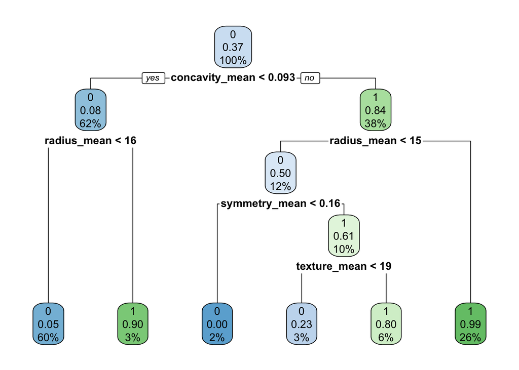

```r
rpart.plot(cancer_tree$fit) #generating a visual of an actual decision tree.
```

So this is just a clearer picture of the options that the model is going through when predicting a diagnosis.

Now we are going to generate our predictions once again.

```r
diagnosis_pred = cancer_tree %>%
  predict(new_data = cancer_test) # Using our testing dataset to predict diagnoses now that we have fit our training dataset to model.
```

Let’s create a new column now in our dataset and calculate our accuracy score

```r
cancer_test %>%
  mutate(diagnosis_pred = diagnosis_pred$.pred_class) %>% #Adding into our testing dataset a column of our predictions
  accuracy(estimate = diagnosis_pred, truth = factor(diagnosis)) # using accuracy() function to calculate accuracy score through comparing the true diagnosis and predicted diagnosis.
```

```
## # A tibble: 1 × 3
##   .metric  .estimator .estimate
##   <chr>    <chr>          <dbl>
## 1 accuracy binary         0.906
```

So with the added on features we can see that our accuracy score went up from about 88.8% to about 90.64%, so adding the extra features did improve our accuracy.

Now that we’ve added in our extra features and it has indeed improved our accuracy score let’s see if we can’t improve this score further by testing other models.

# Random Forest

Why don’t we try random forests next in improving our accuracy scores. A random forest model allows us to build a large collection of trees to improve our performance in making accurate predictions. It basically adds an extra layer of randomness to the model. We are basically creating at time hundreds of extra trees. Where at each split in the tree we choose a random subset of features to use. A random forest essentially is a more complex version of a bagged decision tree. Because I did not use a bagged decision tree in this data exploration so far, I want to go over what this type of model does and why it’s a foundational part of random forests. A bagged decision tree is based off a concept bootstrapping. What bootstrapping means is that it’s taking a dataset and creating dozens or hundreds of copies of it. So let’s take our training set for example. It’s taking this representation of data and then creating copies of this data but in different orders and always the same size sample.

So why don’t we see if this type of model could improve our prediction accuracy. Let’s split our data quickly and then fit our model once again this time using the function `rand_forest()`.

```r
set.seed(9) # Doing once again to replicate our results
cancer_split = initial_split(cancer, prop = 0.7) #Splitting our dataset 70/30.

cancer_train = training(cancer_split) # Assigning slit datasets to our testing and training variables
cancer_test = testing(cancer_split)

fit_rf = rand_forest() %>%
  set_mode(mode = "classification") %>%
  fit(factor(diagnosis) ~ radius_mean + texture_mean + concavity_mean + symmetry_mean,
      data = cancer_train) # We are using our training data NOT our testing data. We need our testing dataset for assessing how accurate our model is in predicting diagnoses. We also need to make sure that our diagnosis variables is categorical so adding factor() in
```

Now let’s generate once again our predictions using our testing dataset and see how well we did.

```r
pred_rf = fit_rf %>%
  predict(new_data = cancer_test) # Here we are generating our predictions for our testing dataset

cancer_test %>%
  mutate(diagnosis_pred = pred_rf$.pred_class) %>% # mutating our testing dataset to include column of our predictions made
  accuracy(truth = factor(diagnosis), estimate = diagnosis_pred) # using accuracy() function to calculate accuracy score through comparing the true diagnosis and predicted diagnosis.
```

```
## # A tibble: 1 × 3
##   .metric  .estimator .estimate
##   <chr>    <chr>          <dbl>
## 1 accuracy binary         0.942
```

So now that we’ve used our random forest model, our accuracy has improved even more than previously where we now have an accuracy score of ~ 94.15%

We’ve improved our accuracy quite a bit through creating more complex models, but there’s other factors that can make our models even more complex and adaptive. The last model that I would like to try before we go into hyperparameters and cross validation in order to help prevent overfitting is gradient boosting models.

This model is even more complex than a random forest because instead of creating an ensemble of deep independent trees the gradient bossting model is creating an ensemble of shallow trees and using the previous model learning from the model and improving upon it in the next model. So let’s see how much this is going to improve our accuracy.

```r
boost_fit = boost_tree() %>% #using boost_tree() function now to generate a gradient boost model fit with our training dataset
  set_mode(mode = "classification") %>% # setting our mode to classification
  fit(factor(diagnosis) ~ radius_mean + texture_mean + concavity_mean + symmetry_mean, data = cancer_train) # using `fit()` function to fit features to model
```

Now let’s create some predictions using our testing dataset.

```r
boost_pred = boost_fit %>%
  predict(new_data = cancer_test) # creating predictions using our testing dataset

cancer_test %>%
  mutate(diagnosis_pred = boost_pred$.pred_class) %>% # adding column in our cancer dataset of our predicted values
  accuracy(truth = factor(diagnosis), estimate = diagnosis_pred) #calculating accuracy score
```

```
## # A tibble: 1 × 3
##   .metric  .estimator .estimate
##   <chr>    <chr>          <dbl>
## 1 accuracy binary         0.930
```

So interestingly our accuracy actually goes down in comparison to the random forest, with a value of 92.98%. While, I’m surprised by this, but it actually leads perfectly into what I wanted to focus on next. What I would like to know is if we adjust some of our hyperparameters, if our gradient boost model accuracy will go up.

When we are discussing GBM hyperparameters, there are really two specific categories we can focus on. So our two categories that we can focus on are: 1. Boosting hyperparemeters 2. Tree-specific hyperparameters

So what do these categories exactly mean? First off, I would like to first really clarify what hyperparameters means. Hyperparameters basically means that we are manually adjusting certain default features that are used in each of our models we use.

Let’s focus now on what the categories of focus in gradient boost model hyperparameters mean.

First, when we are talking about specifically about boosting hyperparamers what we can adjust are: 1. Number of trees we use in the ensemble 2. Learn rate: which means we are adjusting how quickly our algorithm is learning from the previous trees (which personally, I am very interested in figuring out how this affects accuracy and also usually ranges from 0-1)

Second, when we are talking about tree-specific hyperparameters, we are talking about two areas to adjust: 1. Tree Depth: So controls the depth of our individual trees (usually 3-8) 2. Minimum observations in leaf nodes: Usually 5-15.

So instead of taking our default values of our `boost_tree()` function why don’t we change the number of trees we use in the ensemble, the tree depth, and the learn rate. So the variables we are going to set ourselves specifically are: 1. `trees`: Lets try 550 here 2. `tree_depth`: Let’s try 4 3. `learn_rate`: And here let’s try 0.8 The thinking behind these values are that I’m sort of trying to avoid the model possibly being overfitted so I don’t want it to do too many trees or too much into depth, so going somewhere in between. In terms of the learn_rate, I’m sort of thinking that if the learn rate is higher and it takes longer to learn from previous model maybe it’ll be more accurate Let’s do this now.

```r
boost_fit = boost_tree(trees = 550,
                       tree_depth = 4,
                       learn_rate = 0.8) %>% # setting my values here manually.
  set_mode(mode = "classification") %>% #setting mode to classification
  fit(factor(diagnosis) ~ radius_mean + texture_mean + concavity_mean + symmetry_mean, data = cancer_train) # fitting our features to model
```

Now that we have fitting without any issues, let’s generate some predictions

```r
boost_pred = boost_fit %>%
  predict(new_data = cancer_test) # generating predictions using testing dataset not training dataset

cancer_test %>%
  mutate(diagnosis_pred = boost_pred$.pred_class) %>% #adding prediction column in our testing dataset
  accuracy(truth = factor(diagnosis), estimate = diagnosis_pred) # calculating accuracy score
```

```
## # A tibble: 1 × 3
##   .metric  .estimator .estimate
##   <chr>    <chr>          <dbl>
## 1 accuracy binary         0.924
```

So looks like us changing our hyperparameters from the default actually slightly worsened our accuracy where it lowered from 92.98% to 92.39%. This isn’t a huge difference, but I would like to change my values slightly more as I’m not entirely sure what to expect to see if I can improve. So let’s do this next: 1. `trees`: Lets try 600 here 2. `tree_depth`: Let’s try 5 3. `learn_rate`: And here let’s try 0.8 *I would like to leave this the same, just to keep something constant still*

```r
boost_fit = boost_tree(trees = 600,
                       tree_depth = 5,
                       learn_rate = 0.8) %>% # setting my values here manually.
  set_mode(mode = "classification") %>%
  fit(factor(diagnosis) ~ radius_mean + texture_mean + concavity_mean + symmetry_mean, data = cancer_train) #fitting features to model
```

Now let’s generate some new predictions once again.

```r
boost_pred = boost_fit %>%
  predict(new_data = cancer_test) #generating new predictions

cancer_test %>%
  mutate(diagnosis_pred = boost_pred$.pred_class) %>% #creating new column with predictions
  accuracy(truth = factor(diagnosis), estimate = diagnosis_pred) # calculating accuracy score
```

```
## # A tibble: 1 × 3
##   .metric  .estimator .estimate
##   <chr>    <chr>          <dbl>
## 1 accuracy binary         0.930
```

Hmmm, interesting so now we have the exact same value of accuracy as we previously had with our default settings. Let’s increase our trees and tree depth one last time and see how it changes things. So here are our new values to try: 1. `trees`: Lets try 700 here 2. `tree_depth`: Let’s try 6 3. `learn_rate`: And here let’s try 0.8 *I would still like to leave this the same, just to keep something constant still*

```r
boost_fit = boost_tree(trees = 700,
                       tree_depth = 6,
                       learn_rate = 0.8) %>% # setting my values here manually.
  set_mode(mode = "classification") %>%
  fit(factor(diagnosis) ~ radius_mean + texture_mean + concavity_mean + symmetry_mean, data = cancer_train) # fitting features to model
```

Now let’s generate the new predictions. Fingers crossed that it improves.

```r
boost_pred = boost_fit %>%
  predict(new_data = cancer_test) #generating predictions

cancer_test %>%
  mutate(diagnosis_pred = boost_pred$.pred_class) %>% #creating new column in dataset of predictions
  accuracy(truth = factor(diagnosis), estimate = diagnosis_pred) # calculating accuracy score
```

```
## # A tibble: 1 × 3
##   .metric  .estimator .estimate
##   <chr>    <chr>          <dbl>
## 1 accuracy binary         0.924
```

So interesting, it seems that our sweet spot possible is between 600 and 700 trees and 5 and 6 tree depth, because when we increased to 700 and 6 we got an accuracy score again of what we had originally when we manually adjusted our parameters. Let’s try one more time to adjust model with a values between 600 and 700 and 5 and 6 to see if we can improve anymore. Let’s do this: 1. `trees`: Lets try 650 here 2. `tree_depth`: Let’s still try 5 because apparently we need it to remain an intenger and not a float type.  
3. `learn_rate`: And here let’s try 0.8 *I would like to leave this the same, just to keep something constant still*

```r
boost_fit = boost_tree(trees = 650,
                       tree_depth = 5,
                       learn_rate = 0.8) %>% # setting my values here manually.
  set_mode(mode = "classification") %>%
  fit(factor(diagnosis) ~ radius_mean + texture_mean + concavity_mean + symmetry_mean, data = cancer_train) # fitting features to model
```

Now let’s generate some new predictions.

```r
boost_pred = boost_fit %>%
  predict(new_data = cancer_test) #generate predictions

cancer_test %>%
  mutate(diagnosis_pred = boost_pred$.pred_class) %>% #create column of predictions in dataset
  accuracy(truth = factor(diagnosis), estimate = diagnosis_pred) #calculate accuracy score
```

```
## # A tibble: 1 × 3
##   .metric  .estimator .estimate
##   <chr>    <chr>          <dbl>
## 1 accuracy binary         0.930
```

Well it seems that the best we can achieve is 92.98% accuracy with a gradient boosted model.

What I would like to try next is some cross validation.

So what is cross validation exactly. Cross validation is a resampling technique that randomly partitions out our training dataset into V smaller folds that are roughly the same size. This V value is usually 10 folds. And what it does is it trains ~90% of the training set and holds out ~10% of the dataset for assessment or testing how accurate our model is. And from there this is repeated for each fold. Then finally the estimates of these ten folds is averaged out. The reason that this concept is so valuable is because it helps avoid overfitting which is when the model has become so attuned to our dataset that the predictions become extremely accurate on our testing site but if we were to use model on new testing dataset the accuracy would be quite poor.

Now how do we a actually implement this idea? We will need to use several new functions to perform cross validation on our dataset. These functions are: 1. `vfold_cv(data = ..., v = 10)`": this will be used when we are data splitting 2. `fit_resamples()`: this is similar to our fitting steps 3. `collect_metrics`: automatically collects prediction metrics for each fold.

Let’s put this into action now using our dataset. **Note**: We are going to use our `cancer_train` dataset to split into our standard 10 folds. And each fold will roughly be the same size.

```r
cancer_folds = vfold_cv(cancer_train, v = 10) # using out training dataset we're creating ten folds (or splitting into roughly 10 parts)
```

Now let’s fit our model again. We are also going to use random forest with our new variable `cancer_folds`. Especially as we seemed to have the best accuracy with our random forest model.

```r
cancer_rf_rs = rand_forest() %>%
  set_mode(mode = "classification") %>%
  set_engine(engine = "ranger") %>% # Need to manually set this engine now with cross validations
  fit_resamples(factor(diagnosis) ~ radius_mean + texture_mean + concavity_mean + symmetry_mean, resamples = cancer_folds) # Need to use our `fit_resamples()` function for our cross validation not `fit()`
```

Let’s see how our predictions did!

```r
cancer_rf_rs %>%
  collect_metrics() #calculating our prediction averages
```

```
## # A tibble: 2 × 6
##   .metric  .estimator  mean     n std_err .config
##   <chr>    <chr>      <dbl> <int>   <dbl> <chr>
## 1 accuracy binary     0.925    10 0.00541 Preprocessor1_Model1
## 2 roc_auc  binary     0.972    10 0.00491 Preprocessor1_Model1
```

Overall I would say that our random forest model performs the best.

The last thing we can do in our exploration is tuning our hyperparameters in our decision tree model.

We can explore this through the `tune()` function from the `tune` package. This function allows us to put a placeholder for each of the hyperparameters in a decision tree. This allows the model to train several models on resampled training data (which we get through cross validation) to see which models are the best and basically tells us which hyperparameters perform the best without us manually adjusting everything like we did with the gradient boost model.

First we need to `tune` our hyperparameters. The two hyperparameters in decision trees are: 1. `cost_complexity`: which adds a penalty to error rates of more complex trees 2. `tree_depth`: as the name suggest, controls the depth of the tree (how many levels of splits the tree contains)

```r
tree_tune_spec = decision_tree(
  cost_complexity = tune(),
  tree_depth = tune()
) %>% # So what have we done here? Instead of leaving our default values like we usually do when calling our decision tree function we are putting `tune()` as our placeholder of what each hyperparameter value could be. Next we need to set our modes and engine
  set_mode(mode = "classification") %>% # As a reminder need to set to classification because our diagnosis is categorical
  set_engine(engine = "rpart")
```

```r
tree_grid = grid_regular(cost_complexity(),
                         tree_depth(),
                         levels = 6) #creating our grid of possible hyperparameter combos
```

Now let’s tune our model.

```r
tree_tune_fit = tree_tune_spec %>%
  tune_grid(factor(diagnosis) ~ radius_mean + texture_mean + concavity_mean + symmetry_mean,
            resamples = cancer_folds,
            grid = tree_grid
        ) # We need our cross validations dataset and we also need to add in our grid so that it runs through all our possible hyperparameters
```

Let’s see what is our best hyperparameter through once again `collect_metrics()`. For this purpose let’s filter twice. One variable will be accuracy and the other roc_auc.

```r
tree_tune_fit %>%
  collect_metrics() %>% #getting our predictions
  filter(.metric == "accuracy") #filtering for just the accuracy results
```

```
## # A tibble: 36 × 8
##    cost_complexity tree_depth .metric  .estimator  mean     n std_err .config
##              <dbl>      <int> <chr>    <chr>      <dbl> <int>   <dbl> <chr>
##  1   0.0000000001           1 accuracy binary     0.849    10  0.0130 Preproces…
##  2   0.00000000631          1 accuracy binary     0.849    10  0.0130 Preproces…
##  3   0.000000398            1 accuracy binary     0.849    10  0.0130 Preproces…
##  4   0.0000251              1 accuracy binary     0.849    10  0.0130 Preproces…
##  5   0.00158                1 accuracy binary     0.849    10  0.0130 Preproces…
##  6   0.1                    1 accuracy binary     0.849    10  0.0130 Preproces…
##  7   0.0000000001           3 accuracy binary     0.892    10  0.0124 Preproces…
##  8   0.00000000631          3 accuracy binary     0.892    10  0.0124 Preproces…
##  9   0.000000398            3 accuracy binary     0.892    10  0.0124 Preproces…
## 10   0.0000251              3 accuracy binary     0.892    10  0.0124 Preproces…
## # … with 26 more rows
```

It looks like the smaller the cost_complexity the better and actually in terms of tree depth as long as we use a cost_complexity <= 1.584893e-03 the tree depth can be between 6 and 15. And the highest accuracy we get is, ~90.72%

Let’s look at our `roc_auc` now.

```r
tree_tune_fit %>%
  collect_metrics() %>%
  filter(.metric == "roc_auc") #filtering for just the roc_auc results
```

```
## # A tibble: 36 × 8
##    cost_complexity tree_depth .metric .estimator  mean     n std_err .config
##              <dbl>      <int> <chr>   <chr>      <dbl> <int>   <dbl> <chr>
##  1   0.0000000001           1 roc_auc binary     0.813    10  0.0229 Preprocess…
##  2   0.00000000631          1 roc_auc binary     0.813    10  0.0229 Preprocess…
##  3   0.000000398            1 roc_auc binary     0.813    10  0.0229 Preprocess…
##  4   0.0000251              1 roc_auc binary     0.813    10  0.0229 Preprocess…
##  5   0.00158                1 roc_auc binary     0.813    10  0.0229 Preprocess…
##  6   0.1                    1 roc_auc binary     0.813    10  0.0229 Preprocess…
##  7   0.0000000001           3 roc_auc binary     0.916    10  0.0133 Preprocess…
##  8   0.00000000631          3 roc_auc binary     0.916    10  0.0133 Preprocess…
##  9   0.000000398            3 roc_auc binary     0.916    10  0.0133 Preprocess…
## 10   0.0000251              3 roc_auc binary     0.916    10  0.0133 Preprocess…
## # … with 26 more rows
```

So looks like the roc_auc is similar to the accuracy as long as cost_complexity <= 1.584893e-03 the tree depth can be between 6 and 15. And the highest score we get is 0.9181318.

These scores not being largely different in terms of tree depth being a wide range is probably because these features are already such strong determinants of benign vs. malignant.

# Conclusion

I would like to add as well that we likely had already such good accuracy results due to us seeing in our data exploration already very good indicators of features determining if tumor malignant or benign.

In the future if we wanted to know if there were any other features that had clear distinctions to add to our model to possibly get even more of an accurate prediction model for classifying tumors as benign or malignant, we would start again by doing some visualizations to determine what has strong distinctions and then add it to our models.